# Cellen 2

Statistical thinking — generalized linear models

Gavin Simpson

gavin@anivet.au.dk

Aarhus University

2025-03-10

# Introduction

## Introduction

A Gaussian linear models describes the expected value (mean) of the response as a linear combination of the predictor variables

$$y_i = \beta_0 + \beta_1 x_{i1} + \beta_2 x_{i2} + \beta_3 x_{i3} + \cdots + \beta_j x_{ij} + \varepsilon_i$$

Implies that a *constant* change in a predictor leads to a *constant* change in the response

This is intuitive for a response that has a normal distribution: can vary effectively indefinitely in either direction, or over small range (e.g. heights)

This is inappropriate for a wide range of types of response variables common in animal science data sets

## Introduction

Animal science data are often discrete or categorical

Binary (dichotomous) variables

- Suffering from a particular disease
- Obese or normal weight

Count variables

- number of disease recordings per herd
- number of discrete play behaviours observed

Also continuous, positive (or non-negative) data such as concentrations of particular compounds in blood

# Logistic Regression

## Logistic Regression

A *binary* or *dichotomous* variable can take only *one* of two values

Numerically these are coded as `0` and `1` when we fit a logistic regression

- a value of `1` is generally known as the *success* state; more usefully this indicates cases where risk factor or outcome of interest is **present**,
- a value of `0` is the *failure* state; more usefully the **absence** of the risk factor or outcome of interest

Alternatively, we may have a data representing a proportion of *successes* from some total in a set of $m$ trials or experiments

Such variables are strictly bounded at **0** and **1**

## Logistic Regression

Association between high somatic cell count (SCC) & milk yield in dairy cows

Define high SCC as SCC > 125,000 cells ml<sup>-1</sup>

Linear regression line could predict *negative* probability of high SCC

Variance unlikely to be constant; reduced at 0 & 1

```r
scc <- read_csv("data/itve-milk-scc/milk-scc.csv") |>
  rename(
    milk_yield_kg = kgmilk,
    cell_count = cellcount,
    cow_od = cowid
  ) |>
  mutate(
    high_scc = cell_count > 125,
    breed = factor(
      breed,
      levels = c(1,2,3,8),
      labels = c("Red Danish", "Holstein", "Jersey", "Cross-breed")),
    parity = factor(parity))
```

## Logistic regression

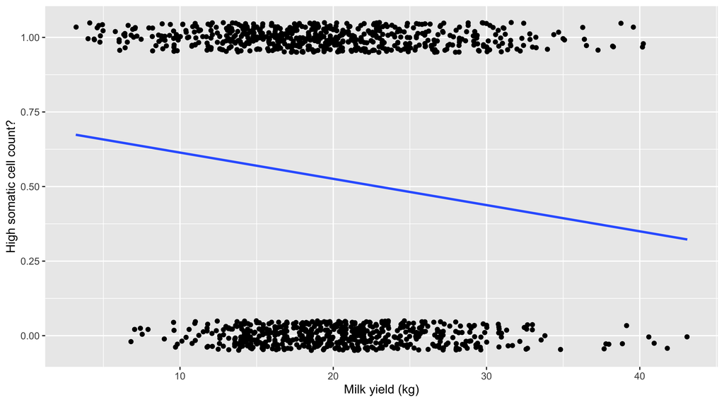

```r
p1 <- ggplot(scc, aes(x = milk_yield_kg, y = as.numeric(high_scc))) +
    geom_jitter(position = position_jitter(height = 0.05)) +
    ylab("High somatic cell count?") + xlab("Milk yield (kg)")
p1 + geom_smooth(method = "lm", se = FALSE)
```

## Logistic Regression

Would like to fit an *s*-shaped curve to the data but we want a linear equation

Can achieve both aims via a *transformation* of the *s*-shaped response to a straight line: logit transformation

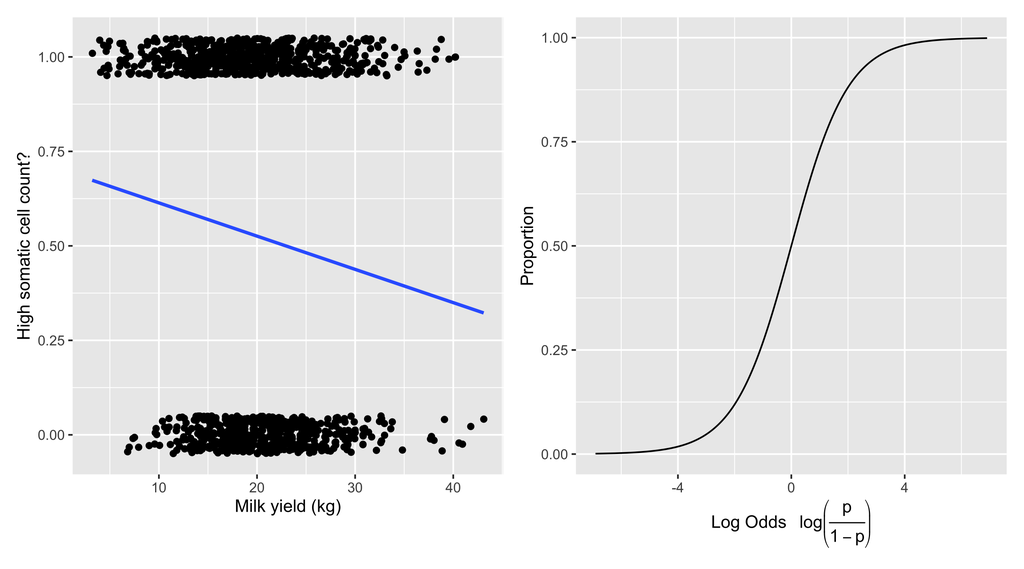

## Logistic Regression

The logistic regression is given by the following equation

$$\log \left ( \frac{p}{1 - p} \right ) = \beta_0 + \beta_{1} x_1$$

$\displaystyle \frac{p}{1 - p}$ is the odds, a measure that compares the probability of an event happening with the probability that it does not happen

If $p$ = 0.25 the odds are $\frac{0.25}{1 - 0.25} = \frac{1}{3}$ or 1 success for every 3 failures

If $p$ = 0.8 the odds are $\frac{0.8}{1 - 0.8} = 4$ or 4 success for each failure

The logit is the natural log of the odds; odds are *non-negative* number, but log odds can be any real number

## Logistic Regression

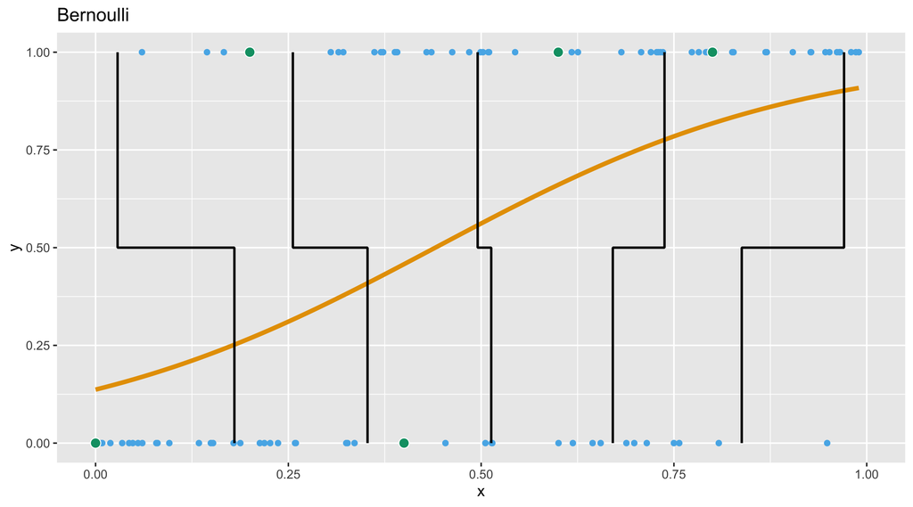

## Logistic Regression

$$\log \left ( \frac{p}{1 - p} \right ) = \beta_0 + \beta_{1} x_1$$

$\beta_0$ a constant term; predicted log-odds of success (high SCC) where $x$ is 0 (0 milk yield)

$\beta_1$ is the slope; predicted change in the log-odds of success (high scc) for a 1 unit increase in $x$ (an additional KG of milk per day)

Because log-odds can take any value

- $\beta_1 \mathsf{> 0}$; increasing $x$ associated with an *increase* in probability of success
- $\beta_1 \mathsf{< 0}$; increasing $x$ associated with a *decrease* in probability of success
- $\beta_1 \mathsf{= 0}$; increasing $x$ has no effect on probability of success

## Logistic Regression

A method known as maximum likelihood (ML) is used to estimate values of $\beta_0$ and $\beta_j$ from the data, the maximum likelihood estimates (MLEs)

So called because these estimates are the ones that make the data most likely under the model

In linear regression we minimised the residual sums of squares

With GLMs we minimise the deviance

Can compare likelihoods of two models using a likelihood ratio test

## Logistic Regression

```r
m <- glm(high_scc ~ milk_yield_kg, data = scc, family = binomial)
m0 <- glm(high_scc ~ 1, data = scc, family = binomial)
anova(m0, m, test = "LRT")
## Analysis of Deviance Table
##
## Model 1: high_scc ~ 1
## Model 2: high_scc ~ milk_yield_kg
##   Resid. Df Resid. Dev Df Deviance  Pr(>Chi)
## 1      1139     1577.2
## 2      1138     1562.2  1   15.056 0.0001044 ***
## ---
## Signif. codes:  0 '***' 0.001 '**' 0.01 '*' 0.05 '.' 0.1 ' ' 1
```

We see that compared to the null model of no change in risk of high SCC, the milk yield of a cow has a statistically significant effect on the probability of high SCC

## Logistic Regression

```r
printCoefmat(coef(summary(m)), digits = 4)
##                Estimate Std. Error z value Pr(>|z|)
## (Intercept)    0.819109   0.195370   4.193 2.76e-05 ***
## milk_yield_kg -0.035740   0.009306  -3.841 0.000123 ***
## ---
## Signif. codes:  0 '***' 0.001 '**' 0.01 '*' 0.05 '.' 0.1 ' ' 1
round(exp(coef(m)), 3)
##   (Intercept) milk_yield_kg
##         2.268         0.965
```

`Estimate` contains the estimates for $\beta_j$ *in log odds*; easier to interpret on odds scale

Odds of high SCC as a non-yielding cow are 2.268

$\beta_1$ is negative, so higher yielding cows are associated with decreased risk of high SCC; for each additional kg of yield, odds of high SCC are multiplied by 0.965 (less than 1 so they decline by about 3.5%)

## Odds ratio

Odds ratio of High SCC where `milk_yield_kg` is 20 and 25 kg

```r
exp(-0.036 * (25 - 20)) # -0.036 is ~ beta_1 from above
## [1] 0.8352702
```

## Odds ratio

Much easier to use *marginaleffects*

```r
m |> comparisons(variables = list(milk_yield_kg = c(20, 25)),
  comparison = "lnoravg", transform = "exp")
##
##  Estimate Pr(>|z|)    S 2.5 % 97.5 %
##     0.836   <0.001 13.0 0.763  0.916
##
## Term: milk_yield_kg
## Type:  response
## Comparison: ln(odds(25) / odds(20))
```

- `"lnoravg"` — `ln` means “natural log” ($\log_{e}$), `or` means “odds ratio”, `avg` means “averaged over the observed data”
- because this would give log-odds (odds ratio on log scale) we need to transform it using `exp` to get odds ratio on the odds scale.

Odds of High SCC ~0.836 *times* lower at 25 kg milk compared with 20 kg.

## Probability of High SCC

To get an estimate of the probability of High SCC at 20 and 25 kg milk yield, we use `avg_predictions()` with `type = "response"`

```r
m |> avg_predictions(variables = list(milk_yield_kg = c(20, 25)),
  type = "response")
##
##  milk_yield_kg Estimate Std. Error    z Pr(>|z|)     S 2.5 % 97.5 %
##             20    0.526     0.0149 35.3   <0.001 906.2 0.497  0.555
##             25    0.481     0.0189 25.5   <0.001 472.4 0.444  0.518
##
## Type:  response
```

## Risk ratio

A risk ratio or relative risk is the ratio of the risk under two conditions

- with or without a risk factor.
- increased milk yield from 20 to 25 kg

$$\text{risk} = \frac{\text{number of cases}}{\text{number at risk}}$$

$$\text{risk ratio} = \frac{\text{risk}_a}{\text{risk}_b}$$

$$\text{risk ratio} = \frac{\Pr(\text{High SCC}\, | \, \text{yield = 25})}{\Pr(\text{High SCC}\, | \, \text{yield = 20})}$$

## Risk ratio

Probability of High SCC at 20 and 25 kg milk yield (repeats above)

```r
m |> avg_predictions(variables = list(milk_yield_kg = c(20, 25)),
  type = "response")
##
##  milk_yield_kg Estimate Std. Error    z Pr(>|z|)     S 2.5 % 97.5 %
##             20    0.526     0.0149 35.3   <0.001 906.2 0.497  0.555
##             25    0.481     0.0189 25.5   <0.001 472.4 0.444  0.518
##
## Type:  response
```

Risk ratio is given by

```r
m |> comparisons(variables = list(milk_yield_kg = c(20, 25)),
  comparison = "lnratioavg", transform = "exp")
##
##  Estimate Pr(>|z|)    S 2.5 % 97.5 %
##     0.915   <0.001 11.9 0.873   0.96
##
## Term: milk_yield_kg
## Type:  response
## Comparison: ln(mean(25) / mean(20))
```

## Logistic Regression

Fitted functions on scale of $\eta$ and *response*

```r
printCoefmat(coef(summary(m)), digits = 4)
##                Estimate Std. Error z value Pr(>|z|)
## (Intercept)    0.819109   0.195370   4.193 2.76e-05 ***
## milk_yield_kg -0.035740   0.009306  -3.841 0.000123 ***
## ---
## Signif. codes:  0 '***' 0.001 '**' 0.01 '*' 0.05 '.' 0.1 ' ' 1
```

Tests of $H_0: \; \beta_j = 0$ are done using a Wald statistic instead of the $t$ test

$$z = \frac{\beta_j - 0}{\mathsf{SE}(\beta_j)}$$

Rather than following a $t$ distribution, Wald statistics are approximately normally distributed; probability of seeing a $z$ as extreme as observed under a standard normal distribution

## Logistic Regression

Fitted functions on the scale of $\eta$ and the response

Over range of data, effect of milk yield on probability of High SCC is approx. linear

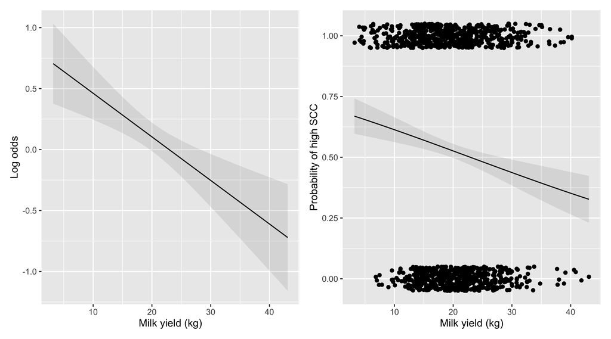

## Logistic Regression

If we extend the range of data we evaluate the model at, we begin to see non-linearity, but also increased uncertainty

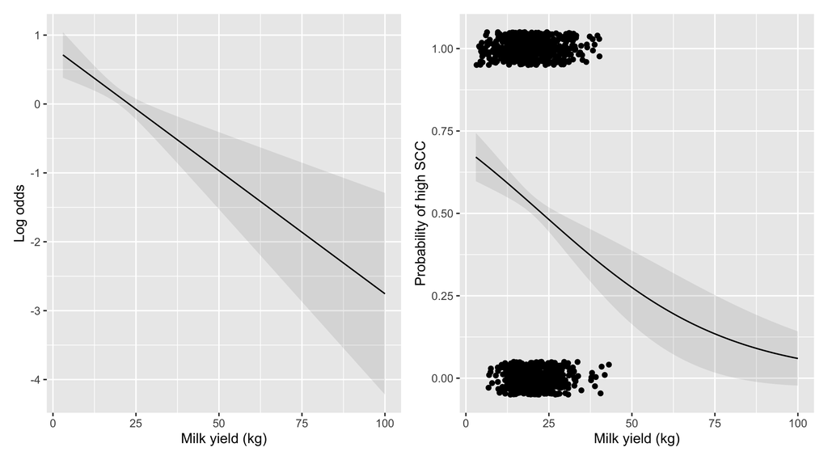

# Generalised Linear Models

## Generalised Linear Models

Generalised Linear Models (GLMs) are a powerful extension to the linear regression model, extending the types of data & conditional distributions that can be modelled beyond the normal or Gaussian distribution of linear regression

Binary (dichotomous) variables can be modelled using logistic regression

Count data can be modelled using Poisson regression

These are two special cases of the broad class of GLMs

Also includes the linear regression as a special case

## Generalised Linear Models

Logistic regression is a special case of the the GLM where the conditional distribution of the response was assumed to be Binomial

GLMs allow the conditional distribution of the response to be any distribution from the exponential family; **Poisson**, **binomial**, **Gaussian**, **gamma**, **multinomial**, …

There are **three** parts to a GLM

- The conditional distribution or $y$
- The linear predictor $\eta$, and
- The link function

Whilst this affords a degree of choice, often natural selections for the conditional distribution of $y$ and the link function arise from type of data being modelled

## Generalised Linear Models

In a GLM we want a model for the expectation of $y$, $\mathsf{E}(y_i)$, which is commonly abbreviated to $\mu_i$

We might model $\mu_i$ as following a Poisson distribution if the data were counts, or as a binomial distribution in the case of dichotomous data, as we did the in the high SCC example

We need to decide which predictor variables and any transformations of them should be used to predict $y$; this is the linear predictor, $\eta$

$$\eta_i = \beta_0 + \beta_{i1} x_{i1} + \beta_{i2} x_{i2} + \cdots + \beta_{ij} \varepsilon$$

Finally we need to map the values from the response scale on to a linear scale, just as we mapped from probabilities to log-odds using the logit transformation. This is the link function, $g()$

## GLM: Link Function

$\mu_i$ is the *expected value* of $Y_i$ given the variables in the model

We write this as $\mathbb{E}(Y_i | \mathbf{X}_i = \mathbf{x}_i)$

So we want to get $\mu_i$ but we have $g(\mu_i)$

The link function maps from the response scale to the linear scaled

$$g(\mu_i) = \eta_i$$

$$\mu_i = g^{-1}(\eta_i)$$

## GLM: Link Function

Sounds complicated but look again at the logistic regression

$$\begin{align*}
\log \left ( \frac{\mu_i}{1 - \mu_i} \right ) & = \eta_i \\
\mathrm{logit}(\mu_i) & = \eta_i \\
\mu_i & = \mathrm{logit}^{-1}(\eta_i)
\end{align*}$$

So we have
$$g(\mu_i) = \mathrm{logit}(\mu_i)$$

The logit transformation linearises the relationship & its *inverse* maps back from the linear scale to the non-linear response scale

Other link functions are suitable for use with other types of GLMs; in a Poisson GLM, as we’ll see next, common to use the log link function

# Poisson GLM

## Poisson GLM

Often, we’ll encounter count data of some sort; *number of cases of a disease in an epidemic*

Counts are strictly *non-negative*; can’t have a count of less than 0

Variance *increases* as a function of the mean (lambda; $\lambda$)

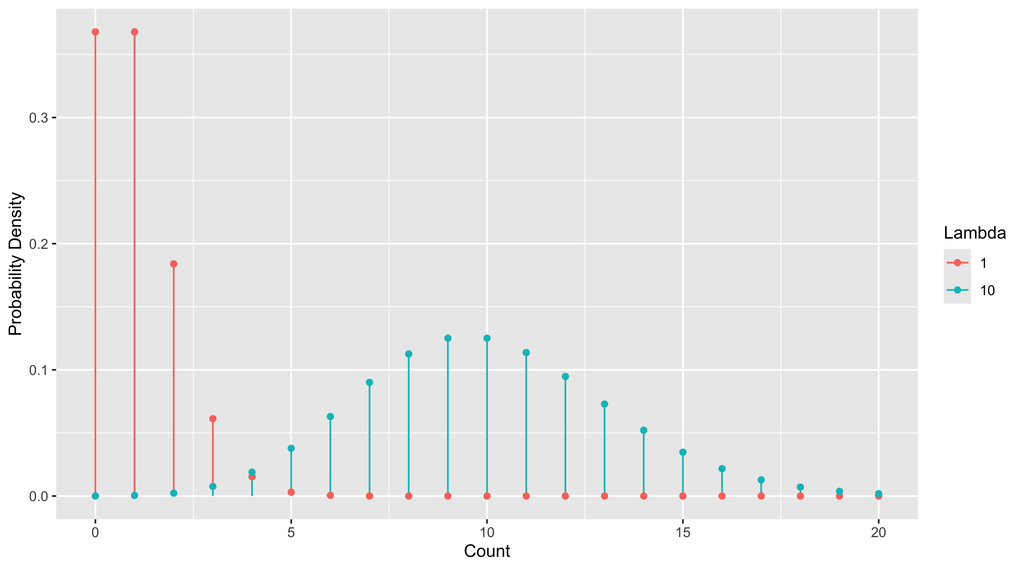

## Poisson GLM

The Poisson distribution is a standard distribution for modelling count data

The Poisson gives the distribution of the number of *things* (individuals, counts, events) in a given sampling interval/effort *if* each event is independent

The Poisson is a simple distribution; defined by a single parameter $\lambda$, which is the mean *and* the variance

The standard link function for a Poisson GLM is the log link; maps non-negative counts on to a linear scale

## Poisson GLM

$$\begin{align*}
y_i & \sim \text{Poisson}(\mu_i) \\
\lambda_i & = \mathbb{E}(y_i) = \mu_i \\
\log(\mu_i) & = \beta_0 + \beta_1 x_1 + \cdots
\end{align*}$$

## Poisson GLM

Example Poisson count data

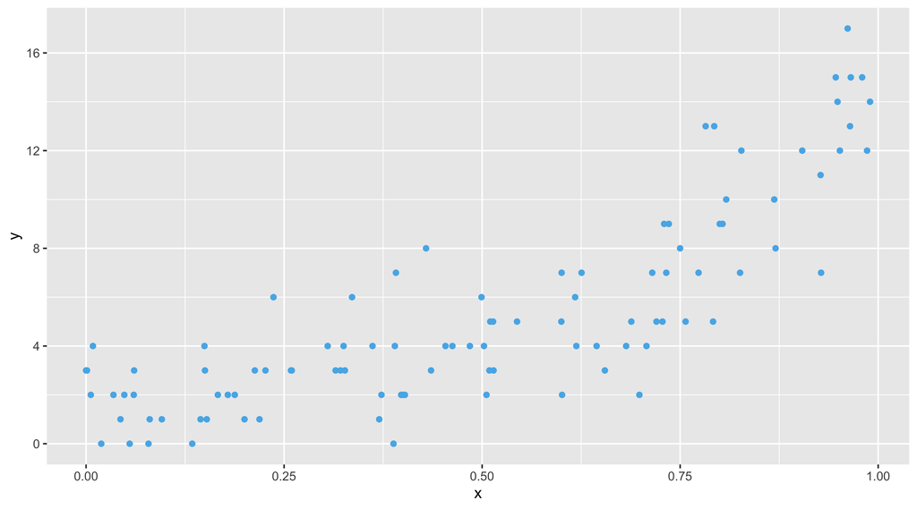

Figure 1

## Poisson GLM

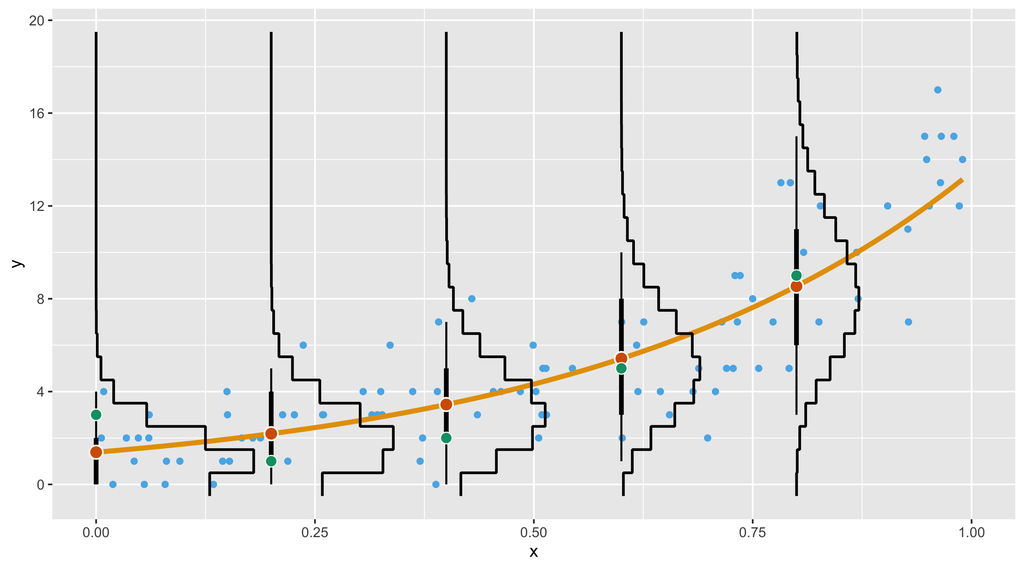

Figure 2

## Poisson GLM: Example

Association between endometritis and breed of cattle in Danish dairy herds

```r
endo <- tibble::tribble(
  ~ breed,    ~ endometritis, ~ count,
  "Holstein", "Yes", 100,
  "Holstein", "No", 400,
  "Jersey", "Yes", 10,
  "Jersey", "No", 190
) |>
mutate(
  breed = factor(breed),
  endometritis = factor(endometritis, levels = c("No", "Yes"))
)
endo
## # A tibble: 4 × 3
##   breed    endometritis count
##   <fct>    <fct>        <dbl>
## 1 Holstein Yes            100
## 2 Holstein No             400
## 3 Jersey   Yes             10
## 4 Jersey   No             190
```

## Poisson GLM: Example

Data like this are common in biology — contingency tables

|  | **Yes** | **No** | **Total** |
| --- | --- | --- | --- |
| **Holstein** | 100 | 400 | *500* |
| **Jersey** | 10 | 190 | *200* |
| **Total** | *110* | *590* | *700* |

A key question of interest is independence of the effects of variables on the cell frequencies

## Poisson GLM: Example

Analysis of deviance table similar to sequential SS from linear regression

```r
endo1 <- glm(count ~ breed + endometritis,
  data = endo, family = poisson(link = "log"))
anova(endo1, test = "Chisq")
## Analysis of Deviance Table
##
## Model: poisson, link: log
##
## Response: count
##
## Terms added sequentially (first to last)
##
##
##              Df Deviance Resid. Df Resid. Dev  Pr(>Chi)
## NULL                             3     523.43
## breed         1   132.83         2     390.60 < 2.2e-16 ***
## endometritis  1   361.54         1      29.05 < 2.2e-16 ***
## ---
## Signif. codes:  0 '***' 0.001 '**' 0.01 '*' 0.05 '.' 0.1 ' ' 1
```

## Poisson GLM: interaction

Add an interaction between `breed` and `endometritis` to the model & refit

```r
endo2 <- update(endo1, . ~ . + breed:endometritis)
summary(endo2)
##
## Call:
## glm(formula = count ~ breed + endometritis + breed:endometritis,
##     family = poisson(link = "log"), data = endo)
##
## Coefficients:
##                             Estimate Std. Error z value Pr(>|z|)
## (Intercept)                  5.99146    0.05000 119.829  < 2e-16 ***
## breedJersey                 -0.74444    0.08811  -8.449  < 2e-16 ***
## endometritisYes             -1.38629    0.11180 -12.399  < 2e-16 ***
## breedJersey:endometritisYes -1.55814    0.34317  -4.540 5.61e-06 ***
## ---
## Signif. codes:  0 '***' 0.001 '**' 0.01 '*' 0.05 '.' 0.1 ' ' 1
##
## (Dispersion parameter for poisson family taken to be 1)
##
##     Null deviance:  5.2343e+02  on 3  degrees of freedom
## Residual deviance: -3.9968e-14  on 0  degrees of freedom
## AIC: 33.517
##
## Number of Fisher Scoring iterations: 3
```

## Poisson GLM: interaction

Compare models using likelihood ratio test

```r
anova(endo1, endo2, test = "LRT")
## Analysis of Deviance Table
##
## Model 1: count ~ breed + endometritis
## Model 2: count ~ breed + endometritis + breed:endometritis
##   Resid. Df Resid. Dev Df Deviance Pr(>Chi)
## 1         1     29.054
## 2         0      0.000  1   29.054 7.04e-08 ***
## ---
## Signif. codes:  0 '***' 0.001 '**' 0.01 '*' 0.05 '.' 0.1 ' ' 1
```

Compare models using AIC

```r
AIC(endo1, endo2)
##       df      AIC
## endo1  3 60.57105
## endo2  4 33.51737
```

# Further data examples

## Butterfly colour

Mayekar & Kodandaramaiah (2017; PLoS One, 12, e0171482) studied determinants of pupal colour (green vs. brown) of a tropical butterfly

Response

- Green vs Brown

Predictors

- time to pupation
- pupal weight
- sex

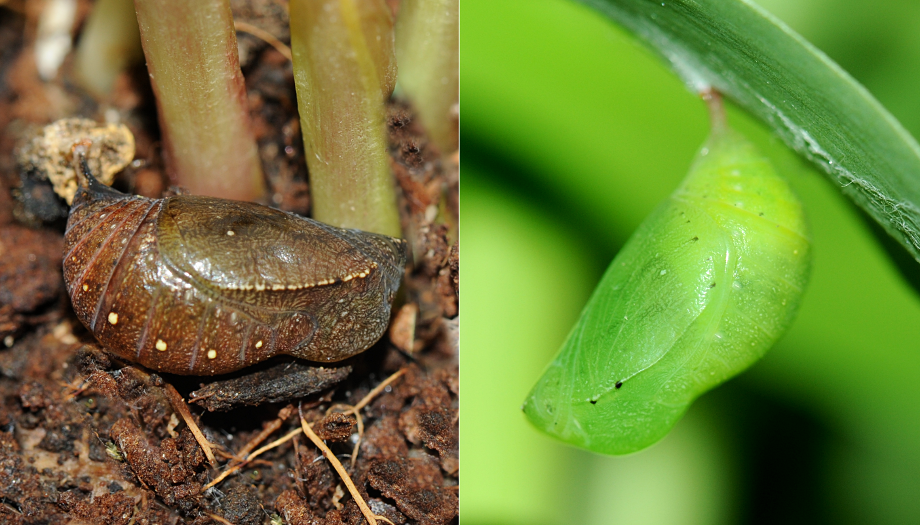

Discuss in your groups:

- what types of data each of the variables is?
- what kind of GLM is appropriate?

## Problematic grizzly bears

Moorehouse *et al* (2016; PLoS One, 11, e0165425) used genetic analyses to determine parentage of bear cubs and cross classified cubs and mothers and whether they caused problems around humans

## Problematic grizzly bears

Table shows the number of cubs and mothers classified by whether they are problematic or not

|  |  | **Mother** |  | **Total** |
| --- | --- | --- | --- | --- |
|  |  | Yes | No |  |
| **Offspring** | Yes | 5 | 18 | *23* |
|  | No | 3 | 50 | *53* |
|  | **Total** | *8* | *68* | *76* |

Discuss in your groups:

- what types of data each of the variables is?
- what kind of GLM is appropriate?

## Cat Owner’s Attitudes

Teng *et al* (2020; PLoS One, 15, e0234190) surveyed cat owners in Australia on factors that might affect affect the prevalence of overweight and obese cats

Body Condition Scores

1. very underweight
2. somewhat underweight
3. ideal
4. chubby/overweight
5. fat/obese

Begging behaviour

1. Never
2. Sometimes
3. Often
4. Always

## Cat Owner’s Attitudes

| Begging? | BCS 1 & 2 | BC 3 | BCS 4 & 5 |
| --- | --- | --- | --- |
| Never | 21 | 266 | 56 |
| Sometimes | 55 | 527 | 162 |
| Often | 14 | 106 | 69 |
| Always | 10 | 47 | 44 |

Discuss in your groups:

- what types of data each of the variables is?
- what kind of GLM is appropriate?